# Tutorial 4: Estimating the Survival Function

Peiyu Liu

2025-09-09

## Introduction

This week, we are exploring non-parametric methods for estimating the survival function. These methods are powerful because they don’t require us to assume a specific underlying probability distribution for survival times. We will focus on the **Kaplan-Meier estimator** and the **Nelson-Aalen estimator**, and learn how to implement them in R.

## Problem 1: Kaplan-Meier Estimation by Hand

Let’s start by understanding the mechanics of the Kaplan-Meier estimator through a manual calculation.

### Scenario

Imagine a small study where 10 patients are followed from the time of surgery. The event of interest is death. The data collected is as follows:

| Patient | Follow-up Time (months) | Status |
| --- | --- | --- |
| 1 | 1 | Death |
| 2 | 4 | Censored |
| 3 | 5 | Death |
| 4 | 6 | Death |
| 5 | 6 | Death |
| 6 | 11 | Censored |
| 7 | 14 | Death |
| 8 | 14 | Censored |
| 9 | 18 | Death |
| 10 | 23 | Death |

### Calculation

The Kaplan-Meier estimate of the survival function S(t) is calculated as a product of probabilities. The formula is:

$$S(t_j) = S(t_{j-1}) \times \frac{r_j -
d_j}{r_j}$$

Where: * **t_j**: Time of the j-th event

- **r_j**: Number of individuals at risk just before time t_j
- **d_j**: Number of events at time t_j

Let’s build the table step-by-step:

| Time (t_j) | At Risk (r_j) | Deaths (d_j) | Censored (c_j) | Interval Survival | Cumulative Survival S(t_j) |
| --- | --- | --- | --- | --- | --- |
| 1 | 10 | 1 | 0 | (10-1)/10 = 0.9 | 1.0 * 0.9 = **0.900** |
| 4 | 9 | 0 | 1 | - | 0.900 |
| 5 | 8 | 1 | 0 | (8-1)/8 = 0.875 | 0.900 * 0.875 = **0.788** |
| 6 | 7 | 2 | 0 | (7-2)/7 ≈ 0.714 | 0.788 * 0.714 = **0.563** |
| 11 | 5 | 0 | 1 | - | 0.563 |
| 14 | 4 | 1 | 1 | (4-1)/4 = 0.75 | 0.563 * 0.75 = **0.422** |
| 18 | 2 | 1 | 0 | (2-1)/2 = 0.5 | 0.422 * 0.5 = **0.211** |
| 23 | 1 | 1 | 0 | (1-1)/1 = 0 | 0.211 * 0 = **0.000** |

*Note: When an individual is censored, they are removed from the “at risk” pool for the next time interval, but the survival probability does not change at the time of censoring.*

## Problem 2: R Session with ‘The Traitors’ Data

Now, let’s apply these concepts using R. We will analyze data from the TV show ‘The Traitors’. The event of interest is when a participant is banished at the round table.

### Setup

First, make sure you have the `survival` package installed and loaded. You will also need to download the `Traitors_Clean.csv` dataset and place it in your R working directory or provide the full file path.

```r
# Load the necessary library for survival analysis
library(survival)

# Load the dataset.
traitors <- read.csv('Traitors_Clean.csv')

# let's look at the first few rows to understand the data
head(traitors)
```

```
##   Season Age Gender  ShowType Affiliation Episode Banished
## 1      1  48    Man Lifestyle    Faithful       2        0
## 2      1  29  Woman  Civilian    Faithful       2        1
## 3      1  33    Man  Civilian    Faithful       3        0
## 4      1  49  Woman Lifestyle    Faithful       3        1
## 5      1  35  Woman  Civilian    Faithful       4        0
## 6      1  35    Man  Civilian    Faithful       4        1
```

### (a) Kaplan-Meier Curve for All Participants

We will fit a Kaplan-Meier model to the entire dataset to estimate the overall survival function.

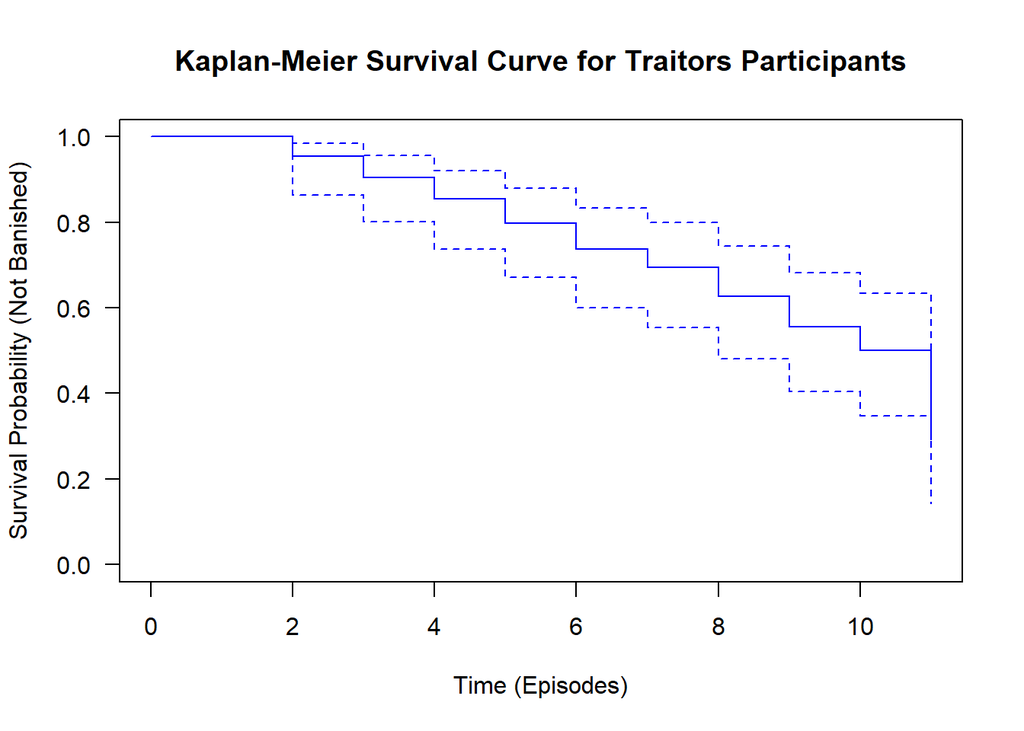

```r
# Fit the Kaplan-Meier model.
# Surv(Episode, Banished) creates the survival object.
# '~ 1' indicates we are fitting a single curve for the whole dataset.
# conf.type="log-log" specifies the method for calculating confidence intervals.
KM <- survfit(Surv(Episode, Banished) ~ 1, data = traitors, conf.type = "log-log")

# Plot the Kaplan-Meier curve
plot(KM,
     xlab = "Time (Episodes)",
     ylab = "Survival Probability (Not Banished)",
     main = "Kaplan-Meier Survival Curve for Traitors Participants",
     col = "blue",
     las = 1) # Makes y-axis labels horizontal
```

### (b) Survival at 5 Episodes

To find the specific survival probability at a certain time point, we can use the `summary()` function.

```r
# Get the summary of the fit, specifically for time = 5
summary(KM, times = 5)
```

```
## Call: survfit(formula = Surv(Episode, Banished) ~ 1, data = traitors,
##     conf.type = "log-log")
##
##  time n.risk n.event survival std.err lower 95% CI upper 95% CI
##     5     46      12    0.798  0.0524        0.671        0.881
```

Based on the output, the estimated survival probability at the end of episode 5 is **0.798**, with a 95% log-log confidence interval of **(0.671, 0.881)** [1]. This means there is about an 80% chance a participant has not been banished by the end of the fifth episode.

### (c) Nelson-Aalen Cumulative Hazard Function

Instead of survival, we can also model the cumulative hazard, which represents the total accumulated risk of the event happening up to a certain time. We use the Nelson-Aalen estimator for this.

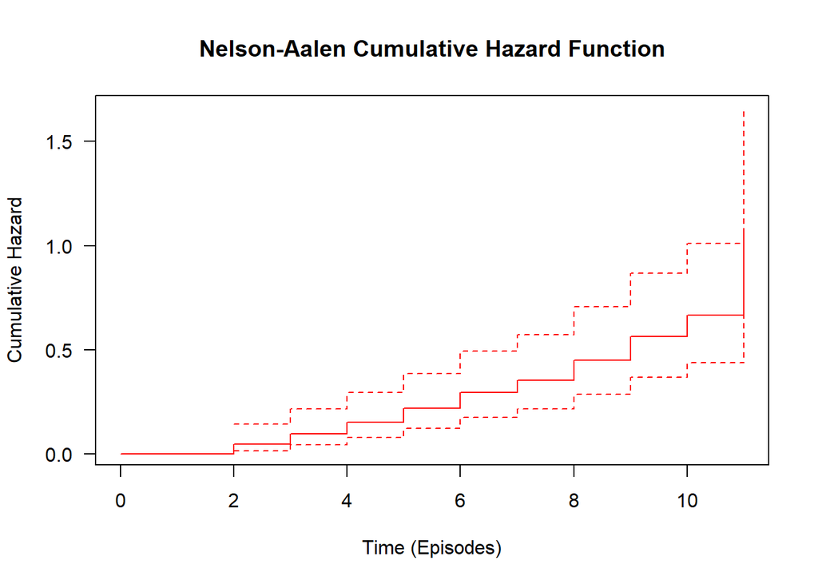

```r
# Fit the Nelson-Aalen estimator
# type="fleming-harrington" is used to get the Nelson-Aalen estimate
FH <- survfit(Surv(Episode, Banished) ~ 1, data = traitors, type = "fleming-harrington")

# Plot the cumulative hazard function
plot(FH,
     fun = "cumhaz",
     xlab = "Time (Episodes)",
     ylab = "Cumulative Hazard",
     main = "Nelson-Aalen Cumulative Hazard Function",
     col = "red",
     las = 1)
```

This plot shows how the risk of being banished accumulates over the episodes.

### (d) Comparing “Gamers” vs. “Non-Gamers”

A key question is whether players with prior experience on strategy-based reality shows (“Gamers”) have different survival rates than others (“Non-Gamers”). We can investigate this by creating stratified Kaplan-Meier curves.

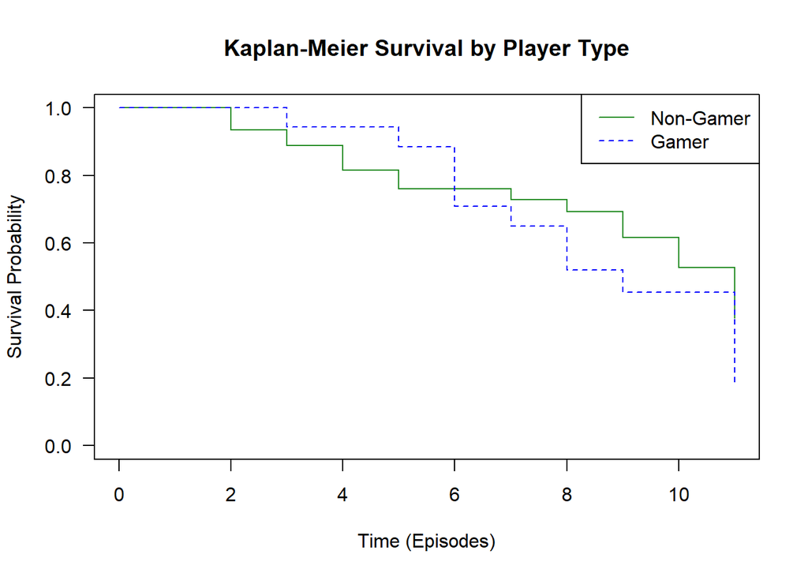

```r
# First, create a new binary variable 'Gamer'.
# it will be 1 if ShowType is "Gamer", and 0 otherwise.
traitors$Gamer <- as.numeric(traitors$ShowType == "Gamer")

# fit a stratified Kaplan-Meier model, with separate curves for each group.
KM.gamer <- survfit(Surv(Episode, Banished) ~ Gamer, data = traitors)

# Plot the two curves on the same graph
plot(KM.gamer,
     col = c("forestgreen", "blue"), # Assign colors to the groups
     lty = c(1, 2), # Assign line styles (solid, dashed)
     xlab = "Time (Episodes)",
     ylab = "Survival Probability",
     main = "Kaplan-Meier Survival by Player Type",
     las = 1)

# Add a legend to identify the curves
legend("topright",
       legend = c("Non-Gamer", "Gamer"),
       col = c("forestgreen", "blue"),
       lty = c(1, 2))
```

### (e) Median Survival Time by Group

The median survival time is the time at which the survival probability drops to 50%. It gives us a single number to summarize and compare the typical survival of each group.

```r
# Printing the survfit object directly gives the median survival
print(KM.gamer)
```

```
## Call: survfit(formula = Surv(Episode, Banished) ~ Gamer, data = traitors)
##
##          n events median 0.95LCL 0.95UCL
## Gamer=0 46     18     11       9      NA
## Gamer=1 19     12      9       7      NA
```

From the output, we can report the estimated median survival times:

**Non-Gamers (Gamer=0):** The median survival is 11 episodes. This means half of the non-gamers are expected to be banished by episode 11.

**Gamers (Gamer=1):** The median survival is 9 episodes. This suggests that gamers, on average, are banished earlier than non-gamers.